# Comparing Treatment Programs of Different Durations to Reduce Drug Abuse and High-risk HIV Behavior

Tun Lee Ng

Fall 2017

# Introduction

We consider the University of Massachusetts AIDS Research Unit (UMARU) IMPACT Study (UIS) data, which is made available by Hosmer, Lemeshow and May (2008). The UIS study was a 5-year (1989-1994) collaborative research project comprised of two concurrent randomized trials of residential treatment for drug abuse. The purpose of the study was to compare treatment programs of different planned durations designed to reduce drug abuse and to prevent high-risk HIV behavior. The UIS sought to determine whether alternative residential treatment approaches are variable in effectiveness and whether efficacy depends on planned program duration.

The variables in the dataset are given as folows:

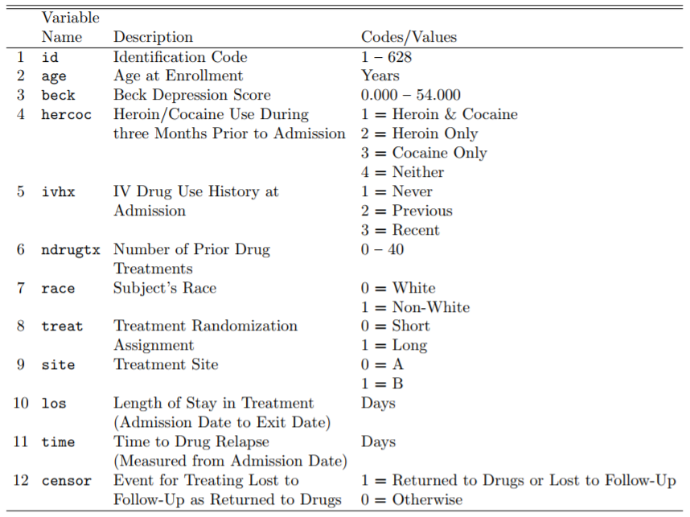

In this survival analysis project, we will assess the effect of two treatment programs, with and without considering the other covariates/factors. Model diagnostics would then be conducted,, including model fit, assessing proportional hazard assumption and identifying influential points. We need the following packages:

```r
library(dplyr)
library(GGally)
library(survival)
library(survminer)
library(tableone)
```

# Exploratory Data Analysis

First, we explore the covariates. Remember to specify the categorical variables `race`, `treat`, `site`, `hercoc` and `ivhx` appropriately.

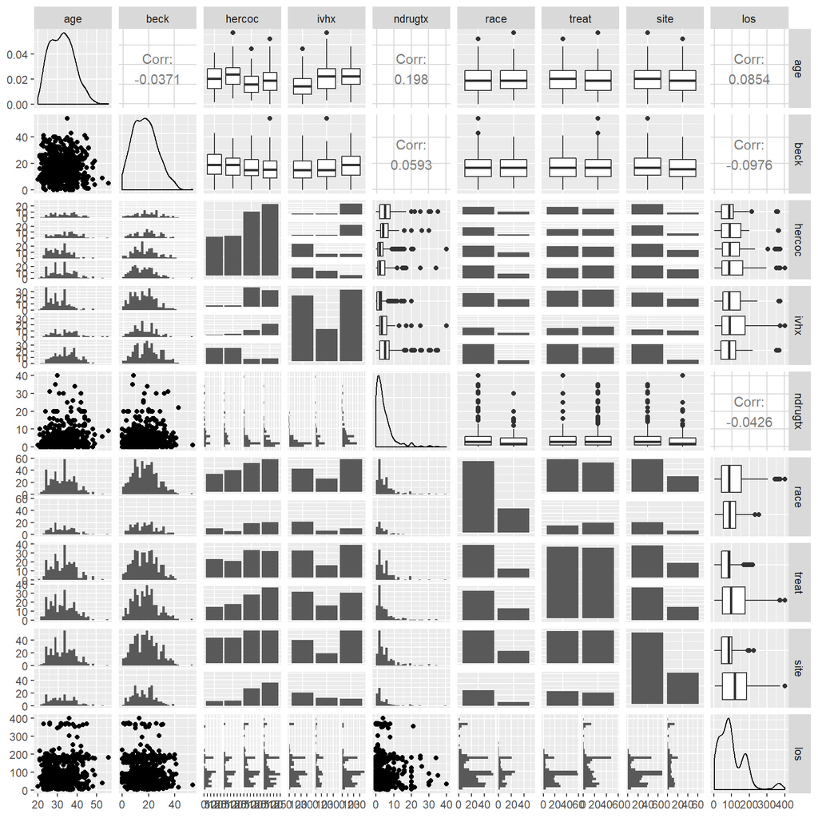

```r
uis <- read.table(file="uis.dat", sep="", header=F, na.strings = ".",
                  col.names=c("id", "age", "beck", "hercoc", "ivhx", "ndrugtx",
                  "race", "treat", "site", "los", "time", "status"))
# for filtering the rows with missing data
uis.new = uis %>% filter(complete.cases(.))

uis.new.id <- uis.new$id
uis.new <- uis.new[ , -which(names(uis.new) %in% c("id"))]
uis.new$race <- as.factor(uis.new$race)
uis.new$treat <- as.factor(uis.new$treat)
uis.new$site <- as.factor(uis.new$site)
uis.new$hercoc <- as.factor(uis.new$hercoc)
uis.new$ivhx <- as.factor(uis.new$ivhx)

ggpairs(uis.new[, -which(names(uis.new) %in% c("time","status"))])
```

It appears that generally long treatment (`treat` = 1) corresponds with longer stay in treatment `los`. In addition, (`site` = 1) seems to have longer `los` than the other treatment site. `hercoc` and `ivhx` reveal another interesting relationship. For `ivhx` = 1 or 2 (never or previous IV drug use), most of the patients only had cocaine or neither cocaine/heroin in the 3 months prior to admission, but the trend is reverse for `ivhx` = 3 (recent IV drug use), where most of the patients had heroin.

# Assess Treatment Effect without Other Variables

We could easily plot Kaplan Meier curves to compare survival under the two treatment regimes.

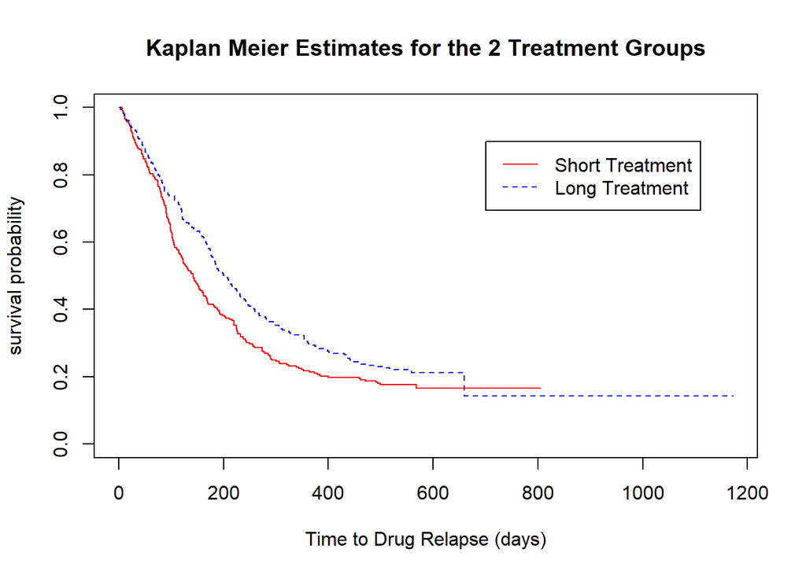

```r
# Kaplan Meier
fit1 <- survfit(Surv(time,status)~treat, data = uis.new)
plot(fit1,  lty=1:2, col= c("red", "blue"), main="Kaplan Meier Estimates for the 2 Treatment Groups",
     ylab="survival probability", xlab="Time to Drug Relapse (days)")
legend(700, 0.9, c("Short Treatment", "Long Treatment"), lty=1:2,col= c("red", "blue"))
```

Long treatment group seems to have better survival than short treatment group. We could also perform a simple logrank test to assess the effect of `treat`. Recall that the logrank test is used to test the null hypothesis that there is no difference between the population survival curves (i.e. the probability of drug-relapse occurring at any time point is the same for each treatment group).

```r
survdiff(Surv(time,status)~treat, data=uis.new, rho=0)
```

```
## Call:
## survdiff(formula = Surv(time, status) ~ treat, data = uis.new,
##     rho = 0)
##
##           N Observed Expected (O-E)^2/E (O-E)^2/V
## treat=0 289      239      212      3.52      6.53
## treat=1 286      225      252      2.96      6.53
##
##  Chisq= 6.5  on 1 degrees of freedom, p= 0.01
```

There exists strong evidence that Hazard ratio of short treatment is different from the hazard ratio of long treatment, ie. treatment effects of the two treatment methods differ. Deploying the Cox (proportional hazard) regression model, we obtain similar results, since the log-rank test is equivant to score test when fitting cox model:

```r
summary(coxph(Surv(time, status) ~ treat, data = uis.new, method = "breslow"))
```

```
## Call:
## coxph(formula = Surv(time, status) ~ treat, data = uis.new, method = "breslow")
##
##   n= 575, number of events= 464
##
##            coef exp(coef) se(coef)      z Pr(>|z|)
## treat1 -0.23686   0.78910  0.09308 -2.545   0.0109 *
## ---
## Signif. codes:  0 '***' 0.001 '**' 0.01 '*' 0.05 '.' 0.1 ' ' 1
##
##        exp(coef) exp(-coef) lower .95 upper .95
## treat1    0.7891      1.267    0.6575     0.947
##
## Concordance= 0.538  (se = 0.012 )
## Likelihood ratio test= 6.48  on 1 df,   p=0.01
## Wald test            = 6.47  on 1 df,   p=0.01
## Score (logrank) test = 6.5  on 1 df,   p=0.01
```

# Assess Treatment Effect Considering Other Variables

The Cox model enables the difference between survival times of particular groups of patients to be tested while allowing for other factors. The response variable in this model would be the instantenous risk of drug relapse given that the patient survived (did not relapse) up to the given time point.

```r
coxph(Surv(time,status)~ age + beck + hercoc + ivhx + ndrugtx + race + treat + site + los,
      data=uis.new, method = "breslow")
```

```
## Call:
## coxph(formula = Surv(time, status) ~ age + beck + hercoc + ivhx +
##     ndrugtx + race + treat + site + los, data = uis.new, method = "breslow")
##
##               coef  exp(coef)   se(coef)       z        p
## age     -0.0208664  0.9793498  0.0082458  -2.531  0.01139
## beck     0.0052843  1.0052983  0.0049238   1.073  0.28318
## hercoc2  0.1512342  1.1632691  0.1513510   0.999  0.31768
## hercoc3 -0.0141796  0.9859204  0.1686813  -0.084  0.93301
## hercoc4 -0.0012074  0.9987933  0.1657084  -0.007  0.99419
## ivhx2    0.1878086  1.2066026  0.1387706   1.353  0.17594
## ivhx3    0.3976501  1.4883232  0.1481964   2.683  0.00729
## ndrugtx  0.0262168  1.0265635  0.0085880   3.053  0.00227
## race1   -0.3058656  0.7364856  0.1160880  -2.635  0.00842
## treat1   0.1376394  1.1475617  0.0969328   1.420  0.15562
## site1    0.4428629  1.5571589  0.1112133   3.982 6.83e-05
## los     -0.0093983  0.9906457  0.0008214 -11.442  < 2e-16
##
## Likelihood ratio test=192.5  on 12 df, p=< 2.2e-16
## n= 575, number of events= 464
```

Here, conclusion differs from the previous section. No evidence of treatment effect. More importantly, the sign of the coefficient of `treat` is reversed. This may be due to confounding effects resulting from imbalance of other covariates between the two treatment groups. We could investigate this as follows:

```r
CreateTableOne(strata = "treat", data = uis.new[,-which(names(uis.new) %in% c("time","status"))])
```

```
##                      Stratified by treat
##                       0             1               p      test
##   n                     289            286
##   age (mean (SD))     32.66 (6.05)   32.10 (6.33)    0.285
##   beck (mean (SD))    17.28 (9.22)   17.46 (9.46)    0.817
##   hercoc (%)                                         0.191
##      1                   60 (20.8)      44 ( 15.4)
##      2                   54 (18.7)      53 ( 18.5)
##      3                   89 (30.8)      83 ( 29.0)
##      4                   86 (29.8)     106 ( 37.1)
##   ivhx (%)                                           0.209
##      1                  108 (37.4)     115 ( 40.2)
##      2                   49 (17.0)      60 ( 21.0)
##      3                  132 (45.7)     111 ( 38.8)
##   ndrugtx (mean (SD))  4.55 (5.16)    4.53 (5.78)    0.961
##   race = 1 (%)           63 (21.8)      82 ( 28.7)   0.072
##   treat = 1 (%)           0 ( 0.0)     286 (100.0)  <0.001
##   site = 1 (%)           91 (31.5)      84 ( 29.4)   0.645
##   los (mean (SD))     80.81 (49.95) 120.91 (92.64)  <0.001
```

It appears that generally long treatment (`treat` = 1) corresponds with longer stay in treatment `los`. We can further verify this by adding the following interaction term into the Cox model.

```r
fit1 <- coxph(Surv(time,status)~ age + beck + hercoc + ivhx + ndrugtx + race + treat + site
              + los + los:treat, data=uis.new, method = "breslow")
summary(fit1)
```

```
## Call:
## coxph(formula = Surv(time, status) ~ age + beck + hercoc + ivhx +
##     ndrugtx + race + treat + site + los + los:treat, data = uis.new,
##     method = "breslow")
##
##   n= 575, number of events= 464
##
##                 coef exp(coef)  se(coef)      z Pr(>|z|)
## age        -0.021760  0.978475  0.008297 -2.622  0.00873 **
## beck        0.006569  1.006590  0.004988  1.317  0.18786
## hercoc2     0.182769  1.200537  0.151858  1.204  0.22876
## hercoc3    -0.029375  0.971052  0.170191 -0.173  0.86296
## hercoc4    -0.010665  0.989392  0.167017 -0.064  0.94909
## ivhx2       0.175906  1.192326  0.138870  1.267  0.20527
## ivhx3       0.376320  1.456913  0.150270  2.504  0.01227 *
## ndrugtx     0.027141  1.027512  0.008613  3.151  0.00163 **
## race1      -0.283822  0.752901  0.116324 -2.440  0.01469 *
## treat1     -0.301467  0.739732  0.176698 -1.706  0.08799 .
## site1       0.487352  1.628000  0.111767  4.360  1.3e-05 ***
## los        -0.012989  0.987095  0.001485 -8.747  < 2e-16 ***
## treat1:los  0.005039  1.005052  0.001713  2.942  0.00326 **
## ---
## Signif. codes:  0 '***' 0.001 '**' 0.01 '*' 0.05 '.' 0.1 ' ' 1
##
##            exp(coef) exp(-coef) lower .95 upper .95
## age           0.9785     1.0220    0.9627    0.9945
## beck          1.0066     0.9935    0.9968    1.0165
## hercoc2       1.2005     0.8330    0.8915    1.6167
## hercoc3       0.9711     1.0298    0.6956    1.3555
## hercoc4       0.9894     1.0107    0.7132    1.3726
## ivhx2         1.1923     0.8387    0.9082    1.5653
## ivhx3         1.4569     0.6864    1.0852    1.9559
## ndrugtx       1.0275     0.9732    1.0103    1.0450
## race1         0.7529     1.3282    0.5994    0.9457
## treat1        0.7397     1.3518    0.5232    1.0459
## site1         1.6280     0.6143    1.3077    2.0267
## los           0.9871     1.0131    0.9842    0.9900
## treat1:los    1.0051     0.9950    1.0017    1.0084
##
## Concordance= 0.743  (se = 0.011 )
## Likelihood ratio test= 201.3  on 13 df,   p=<2e-16
## Wald test            = 189.3  on 13 df,   p=<2e-16
## Score (logrank) test = 203.8  on 13 df,   p=<2e-16
```

Notice that when we include the interaction term, the coefficient estimate becomes closer to that of the model when other covariates are not considered.

# Model Diagnostics

## Cox-Snell residuals to assess model fit

First, we obtain the residuals of the Cox model including `treat` $\times$ `los` interaction term. Then, we plot the empirical cumulative hazard function of the residuals.

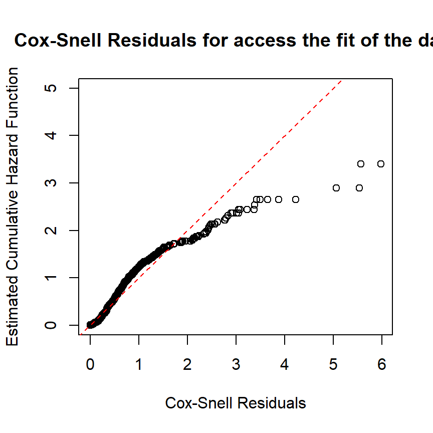

```r
coxsnellres = uis.new$status - resid(fit1, type="martingale")

fitres = survfit( coxph(Surv(coxsnellres, uis.new$status) ~ 1, method = 'breslow'), type='aalen' )

plot(fitres$time,-log(fitres$surv), xlab='Cox-Snell Residuals', ylab='Estimated Cumulative Hazard Function', main='Cox-Snell Residuals for access the fit of the data', ylim = c(0,5))
abline(0,1,col='red',lty=2)
```

If the Cox model sufficiently explains the survival data, then the cumulative hazard function of the residuals should hover around the red-dashed line, ie. residuals should exhibit constant hazard. Here, most of the residuals hover around the red-dashed line.

## Checking proportional hazard function

$H_0$: proportional hazard (PH) assumption is NOT violated.  
$H_1$: proportional hazard (PH) assumption is violated.

```r
cox.zph(fit1)
```

```
##                 rho    chisq        p
## age        -0.00129 7.64e-04 9.78e-01
## beck       -0.06310 1.74e+00 1.87e-01
## hercoc2    -0.02590 3.21e-01 5.71e-01
## hercoc3     0.01661 1.37e-01 7.11e-01
## hercoc4     0.00987 4.77e-02 8.27e-01
## ivhx2       0.02887 3.79e-01 5.38e-01
## ivhx3       0.01754 1.48e-01 7.01e-01
## ndrugtx     0.00347 5.77e-03 9.39e-01
## race1       0.06867 2.23e+00 1.36e-01
## treat1      0.05156 1.45e+00 2.29e-01
## site1      -0.04619 1.04e+00 3.08e-01
## los         0.39287 7.35e+01 1.01e-17
## treat1:los -0.09023 4.41e+00 3.57e-02
## GLOBAL           NA 1.82e+02 7.55e-32
```

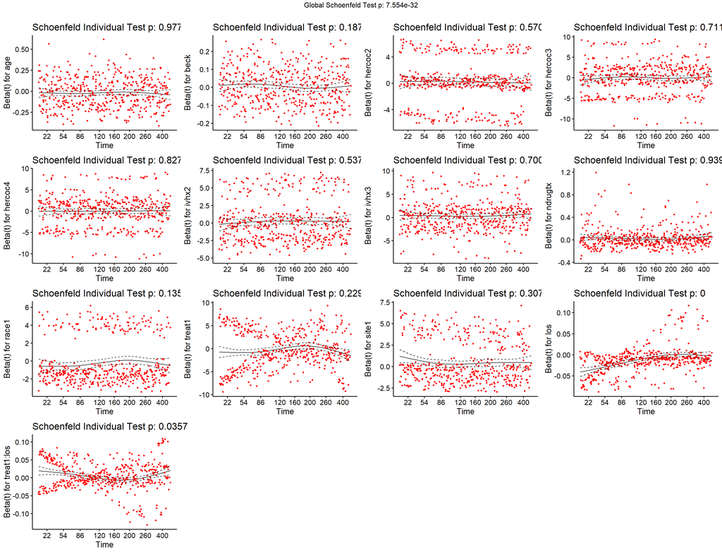

```r
ggcoxzph(cox.zph(fit1))
```

Again, from the plot, the covariate `los` displays systematic departure from a horizontal line, which indicates non proportional hazard, since proportional hazards assumes that estimates do not vary much over time.

## Checking Influential Points

Next, we would like to identify the top three observations that are most influential for the coefficient estimation of `treat`, and plot the DFBETAs for all covariates.

```r
dfbs.resid.df <- resid(fit1, type = "dfbetas")[,match("treat1",names(coef(fit1)))]
dfbs.resid.df <- data.frame(cbind(uis.new.id, dfbs.resid.df, abs(dfbs.resid.df), rank(abs(dfbs.resid.df))))
colnames(dfbs.resid.df) <- c("id","dfbetas","abs(dfbetas)","rank")
dfbs.resid.df <- dfbs.resid.df[order(dfbs.resid.df$`abs(dfbetas)`,decreasing = T),]
dfbs.resid.df[(1:3),]
```

```
##      id   dfbetas abs(dfbetas) rank
## 539 590 0.3885109    0.3885109  575
## 366 405 0.3668918    0.3668918  574
## 405 449 0.3249787    0.3249787  573
```

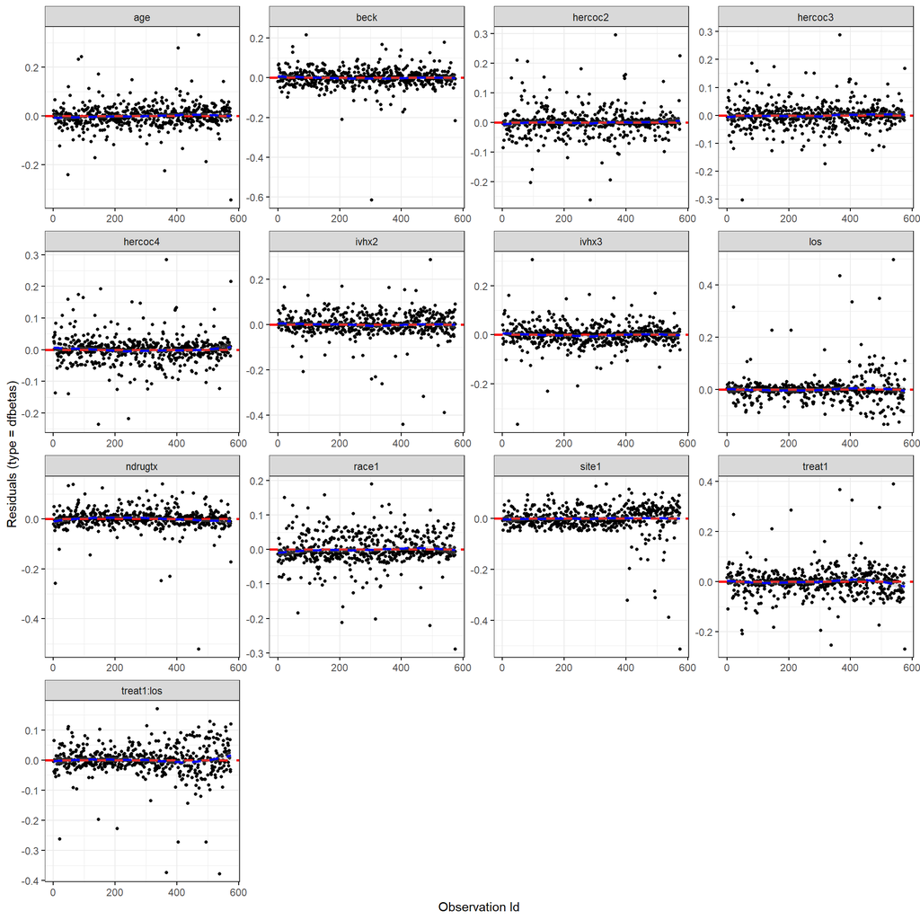

```r
ggcoxdiagnostics(fit1, type = "dfbetas", linear.predictions = FALSE, ggtheme = theme_bw())
```

# References

Hosmer, D.W., Lemeshow, S. & May, S. (2008). Applied Survival Analysis: Regression Modeling of Time-to-Event Data. 2nd ed. John Wiley & Sons, New York, USA.